# IMDb Movie Database

#### Budget by Actor

- Donna Bae has the highest total budget for all her movies with 12.2 billion dollars, followed by Min-sik Choi with 4.2 billion dollars, then Johnny Depp with 2.6 billion dollars.

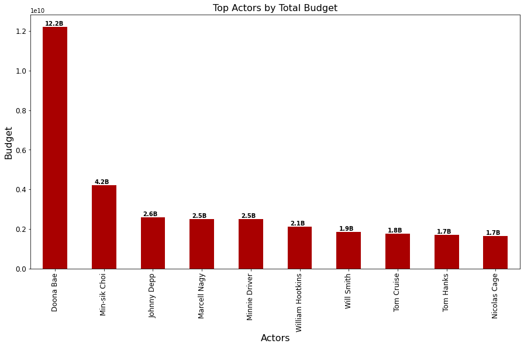

```python
data.groupby('Lead Actor')['Budget'].sum().nlargest(10).plot(kind='bar', figsize=(15,8), color='#a90000');
plt.xlabel('Actors', fontsize=font_size1);
plt.ylabel('Budget', fontsize=font_size1);
plt.title('Top Actors by Total Budget', fontsize=font_size1);
plt.xticks(fontsize= font_size2);
plt.yticks(fontsize= font_size2);

for num, value in enumerate(data.groupby('Lead Actor')['Budget'].sum().nlargest(10)):
        plt.text(num-0.2, value+np.exp(18), str(np.round(value/1000000000, decimals = 1))+'B', fontweight='bold');
```

#### Revenue by Actor

- Harison Ford has the highest total revenue for all his movies with 3.4 billion dollars, followed by Tom Hanks with 3.3 billion dollars, then Johnny Depp with 3.2 billion dollars.

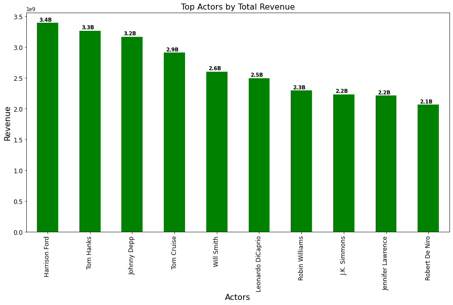

```python
data.groupby('Lead Actor')['Gross Revenue'].sum().nlargest(10).plot(kind='bar', figsize=(15,8), color='#008200');
plt.xlabel('Actors', fontsize=font_size1);
plt.ylabel('Revenue', fontsize=font_size1);
plt.title('Top Actors by Total Revenue', fontsize=font_size1);
plt.xticks(fontsize= font_size2);
plt.yticks(fontsize= font_size2);

for num, value in enumerate(data.groupby('Lead Actor')['Gross Revenue'].sum().nlargest(10)):
        plt.text(num-0.2, value+np.exp(17), str(np.round(value/1000000000, decimals = 1))+'B', fontweight='bold');
```

#### Budget by Director

- Joon-ho Bong has the highest total budget for all his movies with 12.3 billion dollars, followed by Chan-wook Park with 4.2 billion dollars, then Katsuhiro A"tomo with 3.2 billion dollars.

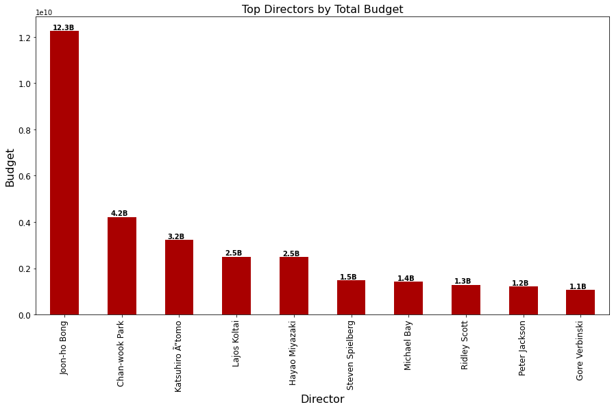

```python
data.groupby('Director Name')['Budget'].sum().nlargest(10).plot(kind='bar', figsize=(15,8), color='#a90000');
plt.xlabel('Director', fontsize=font_size1);
plt.ylabel('Budget', fontsize=font_size1);
plt.title('Top Directors by Total Budget', fontsize=font_size1);
plt.xticks(fontsize= font_size2);
plt.yticks(fontsize= font_size2);

for num, value in enumerate(data.groupby('Director Name')['Budget'].sum().nlargest(10)):
        plt.text(num-0.2, value+np.exp(18), str(np.round(value/1000000000, decimals = 1))+'B', fontweight='bold');
```

#### Revenue by Director

- Steven Spielberg has the highest total revenue for all his movies with 4.1 billion dollars, followed by Michael Bay with 2.1 billion dollars, then Peer Jackson with 2.1 billion dollars.

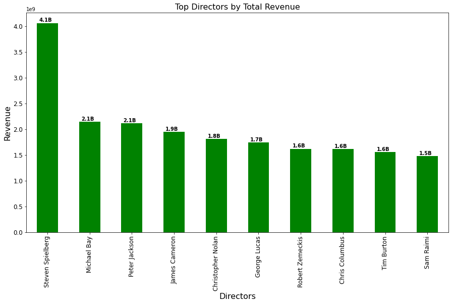

```python
data.groupby('Director Name')['Gross Revenue'].sum().nlargest(10).plot(kind='bar', figsize=(15,8), color='#008200');
plt.xlabel('Directors', fontsize=font_size1);
plt.ylabel('Revenue', fontsize=font_size1);
plt.title('Top Directors by Total Revenue', fontsize=font_size1);
plt.xticks(fontsize= font_size2);
plt.yticks(fontsize= font_size2);

for num, value in enumerate(data.groupby('Director Name')['Gross Revenue'].sum().nlargest(10)):
        plt.text(num-0.2, value+np.exp(17), str(np.round(value/1000000000, decimals = 1))+'B', fontweight='bold');
```

# Multivariate

> Make at least one chart ,write your observation under every chart

#### Top Movies by Movies, Actors, & Directors Likes

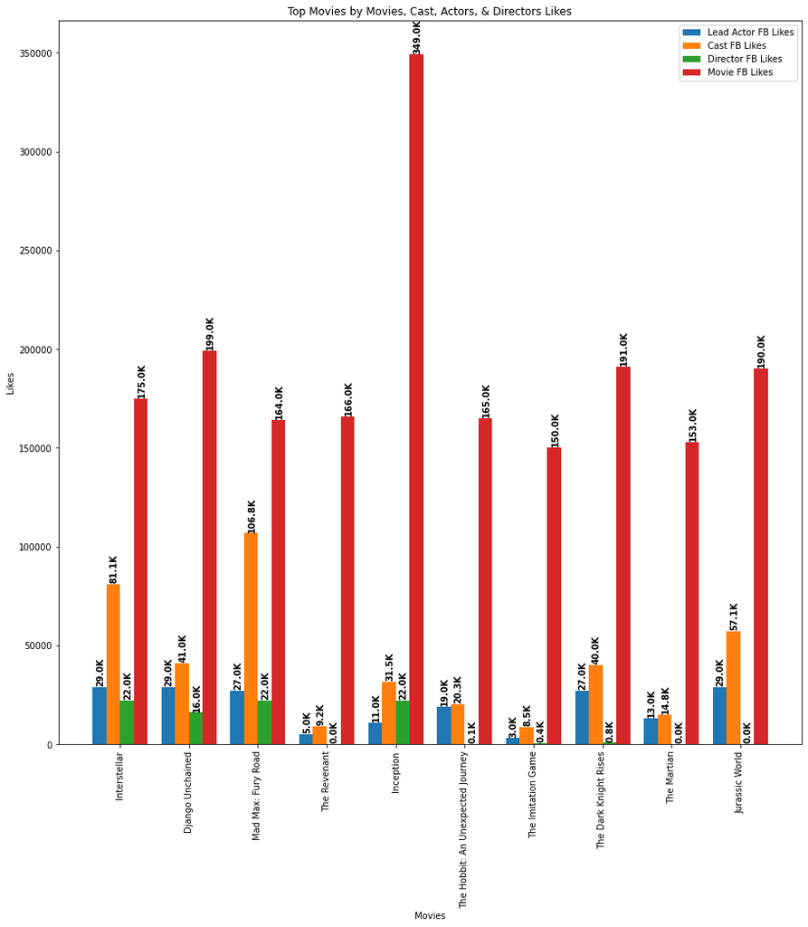

```python
figure, axes = plt.subplots(figsize=(15,15));

x = data.groupby('Title')['Movie FB Likes'].sum().nlargest(10).index
y = data.loc[data['Title'].isin(x)][['Lead Actor FB Likes', 'Cast FB Likes','Director FB Likes','Movie FB Likes']]

loc = 1/(len(y.columns)+1)
location = np.arange(len(x))

for count, value in enumerate(y.columns):
    axes.bar(location+(loc*count),y[value], loc, label=value);

plt.xlabel('Movies');
plt.ylabel('Likes');
plt.title('Top Movies by Movies, Cast, Actors, & Directors Likes');
axes.legend();
plt.xticks(location+loc+loc/2, x,rotation='vertical');

""" The y-values v are both the x-location and the string values for ax.text,
    and conveniently the barplot has a metric of 1 for each bar,
    so the enumeration i is the y-location.
"""
locs = 0
for column in y.columns:

    for num, value in enumerate(y[column]):
        axes.text(location[num]+locs-loc/4, value+1500, str(np.round(value/1000, decimals = 1))+'K', fontweight='bold',rotation='vertical');
    locs+=loc
```

#### Top Countries by Actors & Directors Counts

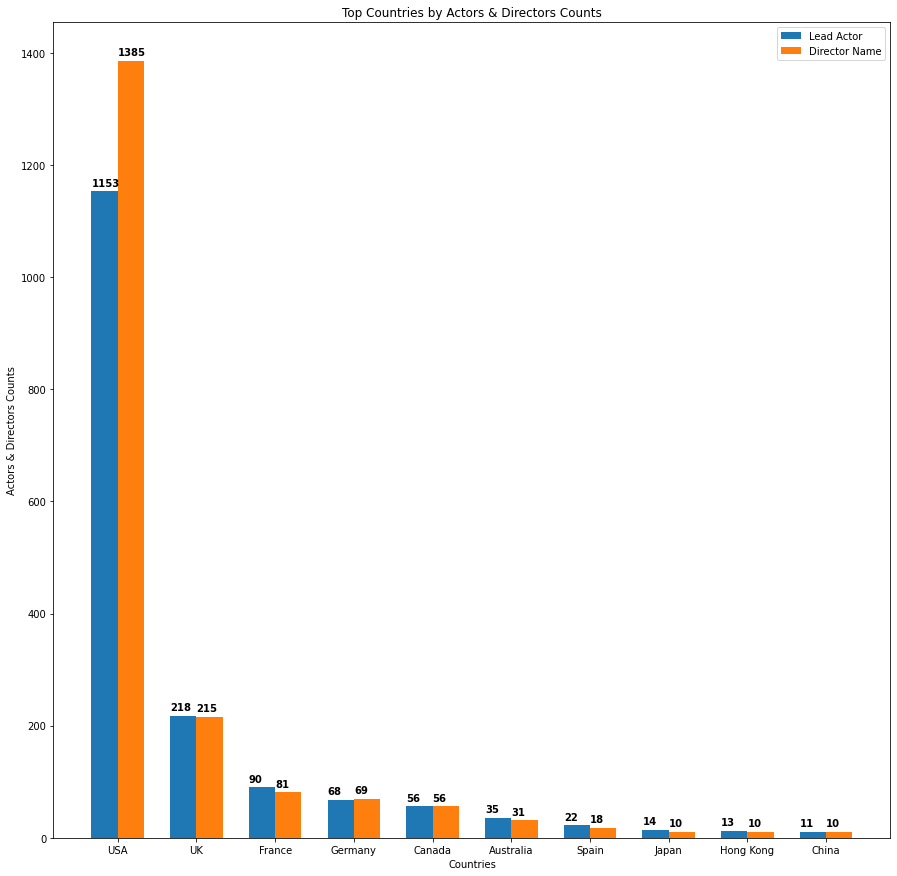

```python
figure, axes = plt.subplots(figsize=(15,15));

x = data.groupby('Country')[['Lead Actor','Director Name']].nunique().nlargest(10,['Lead Actor','Director Name']).index
y =  data.loc[data['Country'].isin(x)].groupby('Country')[['Lead Actor','Director Name']].nunique().sort_values('Lead Actor', ascending=False)

loc = 1/(len(y.columns)+1)
location = np.arange(len(x))

for count, value in enumerate(y.columns):
    axes.bar(location+(loc*count),y[value], loc, label=value);

plt.xlabel('Countries');
plt.ylabel('Actors & Directors Counts');
plt.title('Top Countries by Actors & Directors Counts');
axes.legend();
plt.xticks(location+loc/2, x);

""" The y-values v are both the x-location and the string values for ax.text,
    and conveniently the barplot has a metric of 1 for each bar,
    so the enumeration i is the y-location.
"""
locs = 0
for column in y.columns:

    for num, value in enumerate(y[column]):
        axes.text(location[num]+locs-loc/2, value+10, str(np.round(value, decimals = 1)), fontweight='bold');
    locs+=loc
```